# Untitled Campaign Analysis

Armand Culpepper

2023-07-18

## Marketing Case-study Analysis

The stakeholders at Studio ND., INC. need to know their overall performance relative to their marketing objectives.They needed clarity on best marketing strategy to implement, and executed a variety of approaches while documenting the process. The dataset contains campaigns that have been launched to improve engagement with their audience and further exposure for their brand, from June 2022 to Oct 2022.

##### (The Stakeholder’s Concerns): “What was the prior engagement rate and how can it be improved?”

We need:

```r
r <- na.omit(x$Initial.Views/x$Likes)
r  # the lower, the better for likes; the higher the better for views
```

```
##  [1]  3.608696  8.000000  3.666667  9.261745 22.100000 27.235772 26.041667
##  [8] 28.859060 21.428571 11.145161 39.636364  3.947368  8.783784 44.785276
## [15] 22.702703 24.352332  7.042254 45.393258 57.402597 43.277311  2.870091
## [22] 21.694915 23.595506 12.408759 27.692308 26.633166 53.061224  2.679167
## [29]  4.507431 31.937500  3.135531 14.126394  4.216923
## attr(,"na.action")
## [1] 32 35
## attr(,"class")
## [1] "omit"
```

```r
# For our purposes, lower results are more desirable
```

```r
t <- na.omit(x$Initial.Views/x$Follows)
t  # the lower, the better for follows; the higher the better for views
```

```
##  [1]   9.846154   4.867257  13.745020  56.234097  38.068182  53.763441
##  [7]  48.863636  56.000000  13.549020  94.782609   8.875740  13.000000
## [13] 169.767442  89.361702  53.409091  10.489510 161.600000 168.702290
## [19] 127.950311  46.715328  45.652174  17.346939  72.972973  61.627907
## [25] 106.122449  46.880734 856.000000 120.666667  16.593886
## attr(,"na.action")
## [1]  1 21 28 29 34 35
## attr(,"class")
## [1] "omit"
```

```r
# For our purposes, lower results are more desirable
```

*Note:* Duration is defined by individual campaigns.

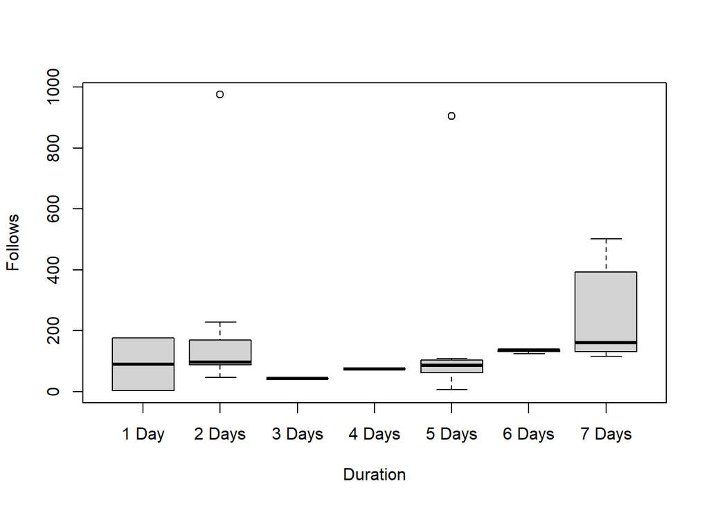

```r
boxplot(Follows ~ Duration, x) #shows relationship between following engagement and campaign length
```

We also collected data to identify KPIs, including but not limited to:

```r
#total views
tv <-sum(na.omit(x$Initial.Views))
tv
```

```
## [1] 257119
```

```r
sum(na.omit(x$Cost)) # total dollar cost
```

```
## [1] 1554.97
```

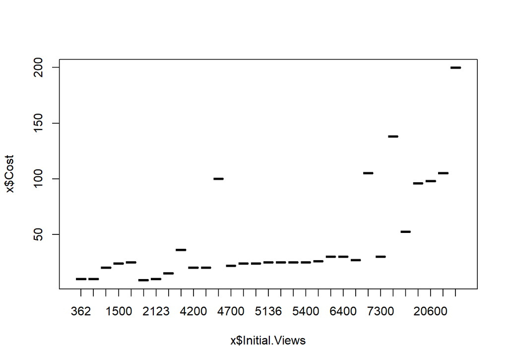

```r
boxplot(x$Cost ~ x$Initial.Views)
```

Here’s the same data in a scatter plot, to further see the potential of a correlation

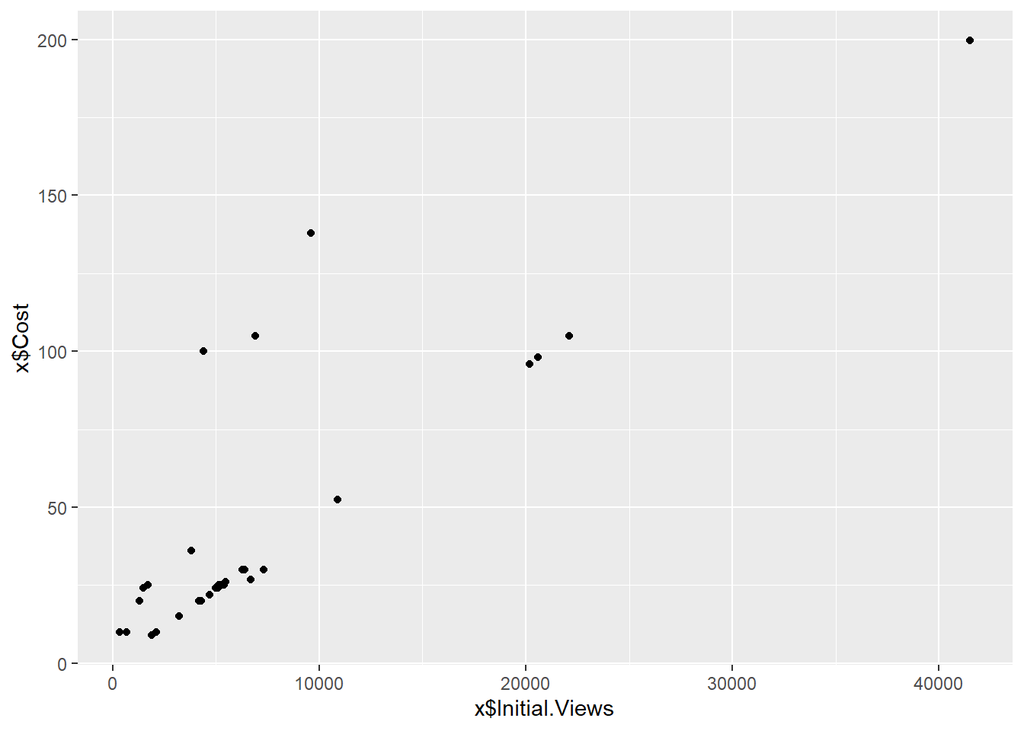

```r
ggplot(data=x) +    #shows correlation $ amount spent and initial view reached
  geom_point(mapping=aes(x$Initial.Views, y=x$Cost))
```

As it turns out, there may very well exist a correlation.

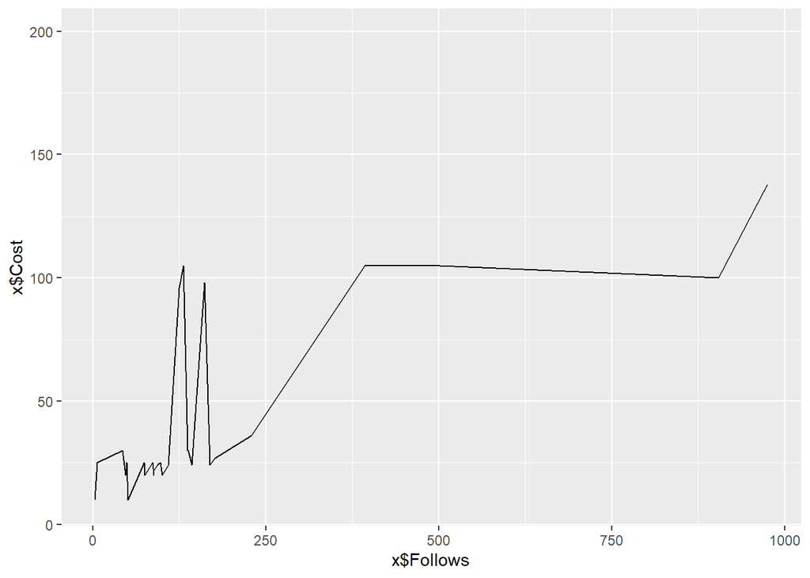

```r
ggplot(data=x) +
  geom_line(mapping=aes(x=x$Follows,y=x$Cost))
```

### Reccomendation:

- Duration

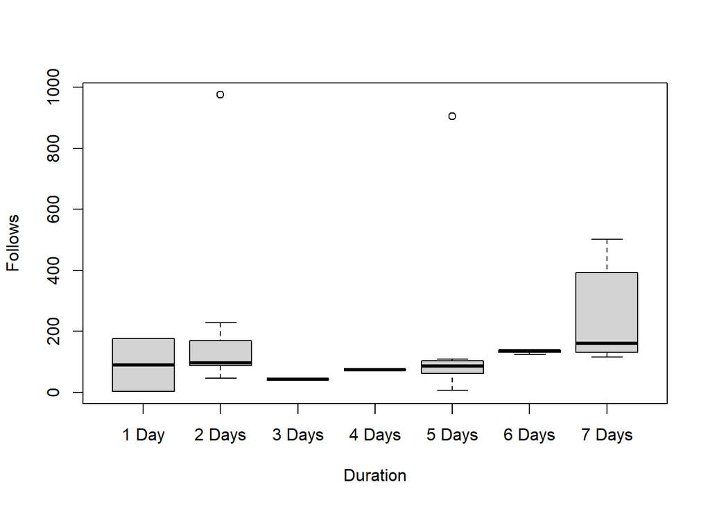

```r
boxplot(Follows ~ Duration, x) #shows relationship between following engagement and campaign length
```

```r
### Using Bayesian logic, the current implication indicates a greater ROI for longer campaigns on average, while factoring in use of resources.
```